# Results: Midterm.sas

Stratum 2: Prior Depression Before Substance Abuse (1=Yes, 0=No) = 1

| Product-Limit Survival Estimates time_subst | Product-Limit Survival Estimates | Product-Limit Survival Estimates Survival | Product-Limit Survival Estimates Failure | Product-Limit Survival Estimates Survival Standard Error | Product-Limit Survival Estimates Number Failed | Product-Limit Survival Estimates Number Left |
| --- | --- | --- | --- | --- | --- | --- |
| 0.0000 |  | 1.0000 | 0 | 0 | 0 | 61 |
| 7.0000 | * | . | . | . | 0 | 60 |
| 11.0000 | * | . | . | . | 0 | 59 |
| 13.0000 |  | 0.9831 | 0.0169 | 0.0168 | 1 | 58 |
| 13.0000 | * | . | . | . | 1 | 57 |
| 13.0000 | * | . | . | . | 1 | 56 |
| 13.0000 | * | . | . | . | 1 | 55 |
| 14.0000 |  | 0.9652 | 0.0348 | 0.0242 | 2 | 54 |
| 14.0000 | * | . | . | . | 2 | 53 |
| 14.0000 | * | . | . | . | 2 | 52 |
| 14.0000 | * | . | . | . | 2 | 51 |
| 15.0000 | * | . | . | . | 2 | 50 |
| 15.0000 | * | . | . | . | 2 | 49 |
| 15.0000 | * | . | . | . | 2 | 48 |
| 16.0000 |  | 0.9451 | 0.0549 | 0.0309 | 3 | 47 |
| 16.0000 | * | . | . | . | 3 | 46 |
| 16.0000 | * | . | . | . | 3 | 45 |
| 16.0000 | * | . | . | . | 3 | 44 |
| 16.0000 | * | . | . | . | 3 | 43 |
| 16.0000 | * | . | . | . | 3 | 42 |
| 16.0000 | * | . | . | . | 3 | 41 |
| 17.0000 | * | . | . | . | 3 | 40 |
| 17.0000 | * | . | . | . | 3 | 39 |
| 18.0000 |  | 0.9208 | 0.0792 | 0.0385 | 4 | 38 |
| 18.0000 | * | . | . | . | 4 | 37 |
| 18.0000 | * | . | . | . | 4 | 36 |
| 18.0000 | * | . | . | . | 4 | 35 |
| 18.0000 | * | . | . | . | 4 | 34 |
| 18.0000 | * | . | . | . | 4 | 33 |
| 18.0000 | * | . | . | . | 4 | 32 |
| 18.0000 | * | . | . | . | 4 | 31 |
| 18.0000 | * | . | . | . | 4 | 30 |
| 18.0000 | * | . | . | . | 4 | 29 |
| 19.0000 | * | . | . | . | 4 | 28 |
| 19.0000 | * | . | . | . | 4 | 27 |
| 19.0000 | * | . | . | . | 4 | 26 |
| 19.0000 | * | . | . | . | 4 | 25 |
| 19.0000 | * | . | . | . | 4 | 24 |
| 19.0000 | * | . | . | . | 4 | 23 |
| 19.0000 | * | . | . | . | 4 | 22 |
| 20.0000 |  | 0.8790 | 0.1210 | 0.0550 | 5 | 21 |
| 20.0000 | * | . | . | . | 5 | 20 |
| 20.0000 | * | . | . | . | 5 | 19 |
| 20.0000 | * | . | . | . | 5 | 18 |
| 21.0000 |  | 0.8301 | 0.1699 | 0.0703 | 6 | 17 |
| 21.0000 | * | . | . | . | 6 | 16 |
| 21.0000 | * | . | . | . | 6 | 15 |
| 21.0000 | * | . | . | . | 6 | 14 |
| 22.0000 |  | 0.7709 | 0.2291 | 0.0868 | 7 | 13 |
| 22.0000 | * | . | . | . | 7 | 12 |
| 22.0000 | * | . | . | . | 7 | 11 |
| 22.0000 | * | . | . | . | 7 | 10 |
| 23.0000 |  | 0.6938 | 0.3062 | 0.1070 | 8 | 9 |
| 23.0000 | * | . | . | . | 8 | 8 |
| 23.0000 | * | . | . | . | 8 | 7 |
| 23.0000 | * | . | . | . | 8 | 6 |
| 23.0000 | * | . | . | . | 8 | 5 |
| 23.0000 | * | . | . | . | 8 | 4 |
| 23.0000 | * | . | . | . | 8 | 3 |
| 24.0000 |  | 0.4625 | 0.5375 | 0.2018 | 9 | 2 |
| 25.0000 |  | 0.2313 | 0.7687 | 0.1922 | 10 | 1 |
| 25.0000 | * | . | . | . | 10 | 0 |

Note:The marked survival times are censored observations.

Summary Statistics for Time Variable time_subst

| Quartile Estimates Percent | Quartile Estimates Point Estimate | Quartile Estimates 95% Confidence Interval Transform | Quartile Estimates 95% Confidence Interval [Lower | Quartile Estimates 95% Confidence Interval Upper) |
| --- | --- | --- | --- | --- |
| 75 | 25.0000 | LOGLOG | 24.0000 | . |
| 50 | 24.0000 | LOGLOG | 23.0000 | . |
| 25 | 23.0000 | LOGLOG | 20.0000 | 25.0000 |

| Mean | Standard Error |
| --- | --- |
| 23.2815 | 0.5041 |

Note:The mean survival time and its standard error were underestimated because the largest observation was censored and the estimation was restricted to the largest event time.

| Summary of the Number of Censored and Uncensored Values Stratum | Summary of the Number of Censored and Uncensored Values prior_depression | Summary of the Number of Censored and Uncensored Values Total | Summary of the Number of Censored and Uncensored Values Failed | Summary of the Number of Censored and Uncensored Values Censored | Summary of the Number of Censored and Uncensored Values Percent Censored |
| --- | --- | --- | --- | --- | --- |
| 1 | 0 | 159 | 18 | 141 | 88.68 |
| 2 | 1 | 61 | 10 | 51 | 83.61 |
| Total |  | 220 | 28 | 192 | 87.27 |

HYPOTHESIS 2a: Survival Curves for Substance Abuse Onset

Stratified by Prior Depression in Offspring

The LIFETEST Procedure

Testing Homogeneity of Survival Curves for time_subst over Strata

| Rank Statistics prior_depression | Rank Statistics Log-Rank | Rank Statistics Wilcoxon |
| --- | --- | --- |
| 0 | 0.64682 | 320.00 |
| 1 | -0.64682 | -320.00 |

| Covariance Matrix for the Log-Rank Statistics prior_depression | Covariance Matrix for the Log-Rank Statistics 0 | Covariance Matrix for the Log-Rank Statistics 1 |
| --- | --- | --- |
| 0 | 6.43625 | -6.43625 |
| 1 | -6.43625 | 6.43625 |

| Covariance Matrix for the Wilcoxon Statistics prior_depression | Covariance Matrix for the Wilcoxon Statistics 0 | Covariance Matrix for the Wilcoxon Statistics 1 |
| --- | --- | --- |
| 0 | 87594.0 | -87594.0 |
| 1 | -87594.0 | 87594.0 |

| Test of Equality over Strata Test | Test of Equality over Strata Chi-Square | Test of Equality over Strata DF | Test of Equality over Strata Pr > Chi-Square |
| --- | --- | --- | --- |
| Log-Rank | 0.0650 | 1 | 0.7988 |
| Wilcoxon | 1.1690 | 1 | 0.2796 |
| -2Log(LR) | 0.2635 | 1 | 0.6078 |

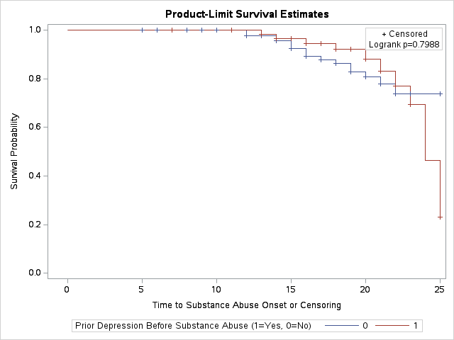

HYPOTHESIS 2a: Cox Regression for Substance Abuse Onset

Effect of PRIOR DEPRESSION in offspring controlling for demographics and social characteristics

The PHREG Procedure

| Model Information |  |  |
| --- | --- | --- |
| Data Set | WORK.SUBSTANCE_ANALYSIS |  |
| Dependent Variable | time_subst | Time to Substance Abuse Onset or Censoring |
| Censoring Variable | censor_subst | Censoring Status for Substance Abuse (1=Censored, 0=Event) |
| Censoring Value(s) | 1 |  |
| Ties Handling | BRESLOW |  |

| Number of Observations Read Number of Observations Used | 220 219 |
| --- | --- |

| Class Level Information Class | Class Level Information Value | Class Level Information Design Variables |
| --- | --- | --- |
| prior_depression | 0 | 0 |
|  | 1 | 1 |
| gender | 1 | 0 |
|  | 2 | 1 |
| marital_status | 1 | 0 |
|  | 2 | 1 |

| Summary of the Number of Event and Censored Values Total | Summary of the Number of Event and Censored Values Event | Summary of the Number of Event and Censored Values Censored | Summary of the Number of Event and Censored Values Percent Censored |
| --- | --- | --- | --- |
| 219 | 28 | 191 | 87.21 |

| Convergence Status |
| --- |
| Convergence criterion (GCONV=1E-8) satisfied. |

| Model Fit Statistics Criterion | Model Fit Statistics Without Covariates | Model Fit Statistics With Covariates |
| --- | --- | --- |
| -2 LOG L | 243.449 | 238.263 |
| AIC | 243.449 | 248.263 |
| SBC | 243.449 | 254.924 |

| Testing Global Null Hypothesis: BETA=0 Test | Testing Global Null Hypothesis: BETA=0 Chi-Square | Testing Global Null Hypothesis: BETA=0 DF | Testing Global Null Hypothesis: BETA=0 Pr > ChiSq |
| --- | --- | --- | --- |
| Likelihood Ratio | 5.1856 | 5 | 0.3936 |
| Score | 4.9306 | 5 | 0.4244 |
| Wald | 4.7544 | 5 | 0.4466 |

| Type 3 Tests Effect | Type 3 Tests DF | Type 3 Tests Wald Chi-Square | Type 3 Tests Pr > ChiSq |
| --- | --- | --- | --- |
| prior_depression | 1 | 0.0000 | 0.9981 |
| gender | 1 | 2.4767 | 0.1155 |
| age | 1 | 0.2779 | 0.5981 |
| social_class | 1 | 0.0000 | 0.9989 |
| marital_status | 1 | 2.1917 | 0.1388 |

| Analysis of Maximum Likelihood Estimates Parameter | Analysis of Maximum Likelihood Estimates | Analysis of Maximum Likelihood Estimates DF | Analysis of Maximum Likelihood Estimates Parameter Estimate | Analysis of Maximum Likelihood Estimates Standard Error | Analysis of Maximum Likelihood Estimates Chi-Square | Analysis of Maximum Likelihood Estimates Pr > ChiSq | Analysis of Maximum Likelihood Estimates Hazard Ratio | Analysis of Maximum Likelihood Estimates Label |
| --- | --- | --- | --- | --- | --- | --- | --- | --- |
| prior_depression | 1 | 1 | -0.0009514 | 0.40534 | 0.0000 | 0.9981 | 0.999 | Prior Depression Before Substance Abuse (1=Yes, 0=No) 1 |
| gender | 2 | 1 | -0.62044 | 0.39424 | 2.4767 | 0.1155 | 0.538 | Gender (1=Male, 2=Female) 2 |
| age |  | 1 | 0.04416 | 0.08377 | 0.2779 | 0.5981 | 1.045 | Age at Interview |
| social_class |  | 1 | -0.0002383 | 0.17675 | 0.0000 | 0.9989 | 1.000 | Social Class (1=Highest, 5=Lowest) |
| marital_status | 2 | 1 | -0.81914 | 0.55330 | 2.1917 | 0.1388 | 0.441 | Marital Status (1=Married, 2=Sep/Div) 2 |

HYPOTHESIS 2a: Cox Regression with PH Assumption Test

The PHREG Procedure

| Model Information |  |  |
| --- | --- | --- |
| Data Set | WORK.SUBSTANCE_ANALYSIS |  |
| Dependent Variable | time_subst | Time to Substance Abuse Onset or Censoring |
| Censoring Variable | censor_subst | Censoring Status for Substance Abuse (1=Censored, 0=Event) |
| Censoring Value(s) | 1 |  |
| Ties Handling | EFRON |  |

| Number of Observations Read Number of Observations Used | 220 219 |
| --- | --- |

| Class Level Information Class | Class Level Information Value | Class Level Information Design Variables |
| --- | --- | --- |
| prior_depression | 0 | 0 |
|  | 1 | 1 |
| gender | 1 | 0 |
|  | 2 | 1 |
| marital_status | 1 | 0 |
|  | 2 | 1 |

| Summary of the Number of Event and Censored Values Total | Summary of the Number of Event and Censored Values Event | Summary of the Number of Event and Censored Values Censored | Summary of the Number of Event and Censored Values Percent Censored |
| --- | --- | --- | --- |
| 219 | 28 | 191 | 87.21 |

| Convergence Status |
| --- |
| Convergence criterion (GCONV=1E-8) satisfied. |

| Model Fit Statistics Criterion | Model Fit Statistics Without Covariates | Model Fit Statistics With Covariates |
| --- | --- | --- |
| -2 LOG L | 243.051 | 237.787 |
| AIC | 243.051 | 247.787 |
| SBC | 243.051 | 254.448 |

| Testing Global Null Hypothesis: BETA=0 Test | Testing Global Null Hypothesis: BETA=0 Chi-Square | Testing Global Null Hypothesis: BETA=0 DF | Testing Global Null Hypothesis: BETA=0 Pr > ChiSq |
| --- | --- | --- | --- |
| Likelihood Ratio | 5.2642 | 5 | 0.3845 |
| Score | 5.0067 | 5 | 0.4151 |
| Wald | 4.8260 | 5 | 0.4375 |

| Type 3 Tests Effect | Type 3 Tests DF | Type 3 Tests Wald Chi-Square | Type 3 Tests Pr > ChiSq |
| --- | --- | --- | --- |
| prior_depression | 1 | 0.0001 | 0.9917 |
| gender | 1 | 2.5246 | 0.1121 |
| age | 1 | 0.2853 | 0.5933 |
| social_class | 1 | 0.0000 | 0.9976 |
| marital_status | 1 | 2.2146 | 0.1367 |

| Analysis of Maximum Likelihood Estimates Parameter | Analysis of Maximum Likelihood Estimates | Analysis of Maximum Likelihood Estimates DF | Analysis of Maximum Likelihood Estimates Parameter Estimate | Analysis of Maximum Likelihood Estimates Standard Error | Analysis of Maximum Likelihood Estimates Chi-Square | Analysis of Maximum Likelihood Estimates Pr > ChiSq | Analysis of Maximum Likelihood Estimates Hazard Ratio | Analysis of Maximum Likelihood Estimates Label |
| --- | --- | --- | --- | --- | --- | --- | --- | --- |
| prior_depression | 1 | 1 | -0.00420 | 0.40509 | 0.0001 | 0.9917 | 0.996 | Prior Depression Before Substance Abuse (1=Yes, 0=No) 1 |
| gender | 2 | 1 | -0.62607 | 0.39403 | 2.5246 | 0.1121 | 0.535 | Gender (1=Male, 2=Female) 2 |
| age |  | 1 | 0.04471 | 0.08370 | 0.2853 | 0.5933 | 1.046 | Age at Interview |
| social_class |  | 1 | 0.0005221 | 0.17670 | 0.0000 | 0.9976 | 1.001 | Social Class (1=Highest, 5=Lowest) |
| marital_status | 2 | 1 | -0.82339 | 0.55330 | 2.2146 | 0.1367 | 0.439 | Marital Status (1=Married, 2=Sep/Div) 2 |

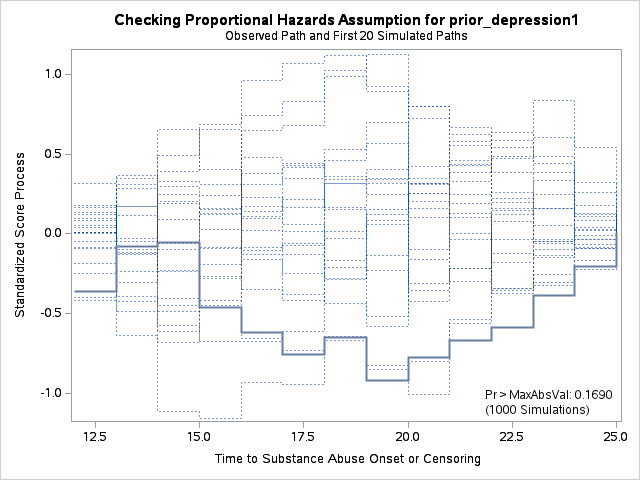

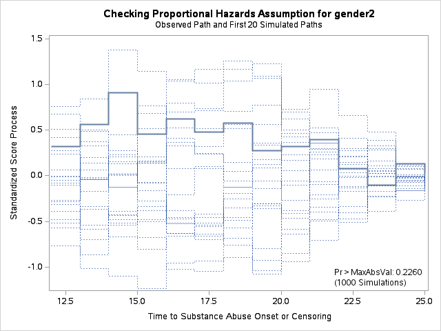

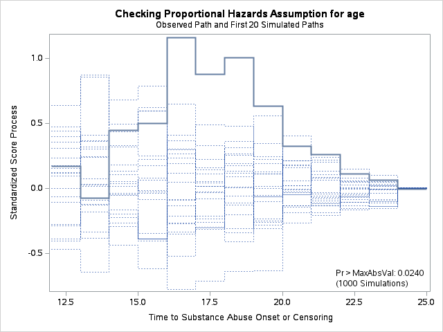

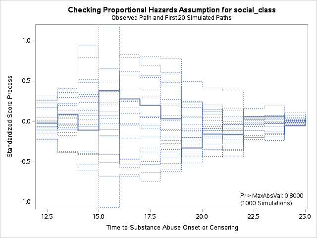

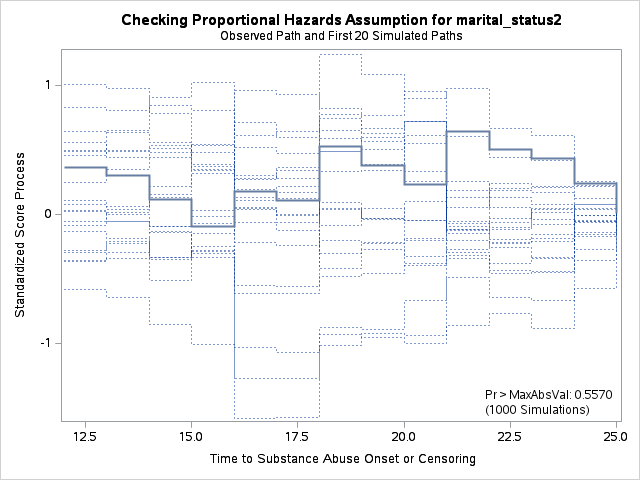

| Supremum Test for Proportionals Hazards Assumption Variable | Supremum Test for Proportionals Hazards Assumption Maximum Absolute Value | Supremum Test for Proportionals Hazards Assumption Replications | Supremum Test for Proportionals Hazards Assumption Seed | Supremum Test for Proportionals Hazards Assumption Pr > MaxAbsVal |
| --- | --- | --- | --- | --- |
| prior_depression1 | 0.9205 | 1000 | 1083616817 | 0.1690 |
| gender2 | 0.9087 | 1000 | 1083616817 | 0.2260 |
| age | 1.1595 | 1000 | 1083616817 | 0.0240 |
| social_class | 0.3837 | 1000 | 1083616817 | 0.8000 |
| marital_status2 | 0.6432 | 1000 | 1083616817 | 0.5570 |

HYPOTHESIS 2b: Survival Curves for Substance Abuse Onset

Stratified by Parental Depression Status

The LIFETEST Procedure

Stratum 1: Parental Depression (0=No, 1=Yes) = 0

| Product-Limit Survival Estimates time_subst | Product-Limit Survival Estimates | Product-Limit Survival Estimates Survival | Product-Limit Survival Estimates Failure | Product-Limit Survival Estimates Survival Standard Error | Product-Limit Survival Estimates Number Failed | Product-Limit Survival Estimates Number Left |
| --- | --- | --- | --- | --- | --- | --- |
| 0.0000 |  | 1.0000 | 0 | 0 | 0 | 95 |
| 7.0000 | * | . | . | . | 0 | 94 |
| 8.0000 | * | . | . | . | 0 | 93 |
| 9.0000 | * | . | . | . | 0 | 92 |
| 9.0000 | * | . | . | . | 0 | 91 |
| 10.0000 | * | . | . | . | 0 | 90 |
| 10.0000 | * | . | . | . | 0 | 89 |
| 11.0000 | * | . | . | . | 0 | 88 |
| 11.0000 | * | . | . | . | 0 | 87 |
| 11.0000 | * | . | . | . | 0 | 86 |
| 11.0000 | * | . | . | . | 0 | 85 |
| 11.0000 | * | . | . | . | 0 | 84 |
| 12.0000 |  | 0.9881 | 0.0119 | 0.0118 | 1 | 83 |
| 12.0000 | * | . | . | . | 1 | 82 |
| 12.0000 | * | . | . | . | 1 | 81 |
| 12.0000 | * | . | . | . | 1 | 80 |
| 12.0000 | * | . | . | . | 1 | 79 |
| 12.0000 | * | . | . | . | 1 | 78 |
| 13.0000 | * | . | . | . | 1 | 77 |
| 13.0000 | * | . | . | . | 1 | 76 |
| 13.0000 | * | . | . | . | 1 | 75 |
| 13.0000 | * | . | . | . | 1 | 74 |
| 13.0000 | * | . | . | . | 1 | 73 |
| 13.0000 | * | . | . | . | 1 | 72 |
| 13.0000 | * | . | . | . | 1 | 71 |
| 14.0000 | * | . | . | . | 1 | 70 |
| 14.0000 | * | . | . | . | 1 | 69 |
| 14.0000 | * | . | . | . | 1 | 68 |
| 14.0000 | * | . | . | . | 1 | 67 |
| 14.0000 | * | . | . | . | 1 | 66 |

[output cut: 66 more lines]

Note:The marked survival times are censored observations.

Summary Statistics for Time Variable time_subst

| Quartile Estimates Percent | Quartile Estimates Point Estimate | Quartile Estimates 95% Confidence Interval Transform | Quartile Estimates 95% Confidence Interval [Lower | Quartile Estimates 95% Confidence Interval Upper) |
| --- | --- | --- | --- | --- |
| 75 | . | LOGLOG | . | . |
| 50 | . | LOGLOG | . | . |
| 25 | . | LOGLOG | 20.0000 | . |

| Mean | Standard Error |
| --- | --- |
| 20.5662 | 0.1917 |

Note:The mean survival time and its standard error were underestimated because the largest observation was censored and the estimation was restricted to the largest event time.

HYPOTHESIS 2b: Survival Curves for Substance Abuse Onset

Stratified by Parental Depression Status

The LIFETEST Procedure

Stratum 2: Parental Depression (0=No, 1=Yes) = 1

| Product-Limit Survival Estimates time_subst | Product-Limit Survival Estimates | Product-Limit Survival Estimates Survival | Product-Limit Survival Estimates Failure | Product-Limit Survival Estimates Survival Standard Error | Product-Limit Survival Estimates Number Failed | Product-Limit Survival Estimates Number Left |
| --- | --- | --- | --- | --- | --- | --- |
| 0.0000 |  | 1.0000 | 0 | 0 | 0 | 125 |
| 5.0000 | * | . | . | . | 0 | 124 |
| 6.0000 | * | . | . | . | 0 | 123 |
| 6.0000 | * | . | . | . | 0 | 122 |
| 7.0000 | * | . | . | . | 0 | 121 |
| 7.0000 | * | . | . | . | 0 | 120 |
| 7.0000 | * | . | . | . | 0 | 119 |
| 7.0000 | * | . | . | . | 0 | 118 |
| 7.0000 | * | . | . | . | 0 | 117 |
| 8.0000 | * | . | . | . | 0 | 116 |
| 8.0000 | * | . | . | . | 0 | 115 |
| 8.0000 | * | . | . | . | 0 | 114 |
| 8.0000 | * | . | . | . | 0 | 113 |
| 9.0000 | * | . | . | . | 0 | 112 |
| 9.0000 | * | . | . | . | 0 | 111 |
| 9.0000 | * | . | . | . | 0 | 110 |
| 9.0000 | * | . | . | . | 0 | 109 |
| 9.0000 | * | . | . | . | 0 | 108 |
| 10.0000 | * | . | . | . | 0 | 107 |
| 10.0000 | * | . | . | . | 0 | 106 |
| 10.0000 | * | . | . | . | 0 | 105 |
| 11.0000 | * | . | . | . | 0 | 104 |
| 11.0000 | * | . | . | . | 0 | 103 |
| 11.0000 | * | . | . | . | 0 | 102 |
| 11.0000 | * | . | . | . | 0 | 101 |
| 12.0000 |  | . | . | . | 1 | 100 |
| 12.0000 |  | 0.9802 | 0.0198 | 0.0139 | 2 | 99 |
| 12.0000 | * | . | . | . | 2 | 98 |
| 12.0000 | * | . | . | . | 2 | 97 |
| 12.0000 | * | . | . | . | 2 | 96 |

[output cut: 96 more lines]

Note:The marked survival times are censored observations.

Summary Statistics for Time Variable time_subst

| Quartile Estimates Percent | Quartile Estimates Point Estimate | Quartile Estimates 95% Confidence Interval Transform | Quartile Estimates 95% Confidence Interval [Lower | Quartile Estimates 95% Confidence Interval Upper) |
| --- | --- | --- | --- | --- |
| 75 | . | LOGLOG | 24.0000 | . |
| 50 | 25.0000 | LOGLOG | 23.0000 | . |
| 25 | 22.0000 | LOGLOG | 18.0000 | 24.0000 |

| Mean | Standard Error |
| --- | --- |
| 22.6239 | 0.4600 |

Note:The mean survival time and its standard error were underestimated because the largest observation was censored and the estimation was restricted to the largest event time.

| Summary of the Number of Censored and Uncensored Values Stratum | Summary of the Number of Censored and Uncensored Values depress_parent | Summary of the Number of Censored and Uncensored Values Total | Summary of the Number of Censored and Uncensored Values Failed | Summary of the Number of Censored and Uncensored Values Censored | Summary of the Number of Censored and Uncensored Values Percent Censored |
| --- | --- | --- | --- | --- | --- |
| 1 | 0 | 95 | 7 | 88 | 92.63 |
| 2 | 1 | 125 | 21 | 104 | 83.20 |
| Total |  | 220 | 28 | 192 | 87.27 |

HYPOTHESIS 2b: Survival Curves for Substance Abuse Onset

Stratified by Parental Depression Status

The LIFETEST Procedure

Testing Homogeneity of Survival Curves for time_subst over Strata

| Rank Statistics depress_parent | Rank Statistics Log-Rank | Rank Statistics Wilcoxon |
| --- | --- | --- |
| 0 | -4.5325 | -561.00 |
| 1 | 4.5325 | 561.00 |

| Covariance Matrix for the Log-Rank Statistics depress_parent | Covariance Matrix for the Log-Rank Statistics 0 | Covariance Matrix for the Log-Rank Statistics 1 |
| --- | --- | --- |
| 0 | 6.54120 | -6.54120 |
| 1 | -6.54120 | 6.54120 |

| Covariance Matrix for the Wilcoxon Statistics depress_parent | Covariance Matrix for the Wilcoxon Statistics 0 | Covariance Matrix for the Wilcoxon Statistics 1 |
| --- | --- | --- |
| 0 | 95224.0 | -95224.0 |
| 1 | -95224.0 | 95224.0 |

| Test of Equality over Strata Test | Test of Equality over Strata Chi-Square | Test of Equality over Strata DF | Test of Equality over Strata Pr > Chi-Square |
| --- | --- | --- | --- |
| Log-Rank | 3.1406 | 1 | 0.0764 |
| Wilcoxon | 3.3051 | 1 | 0.0691 |
| -2Log(LR) | 4.3197 | 1 | 0.0377 |

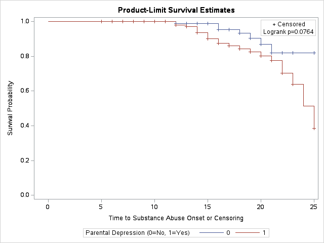

HYPOTHESIS 2b: Cox Regression for Substance Abuse Onset

Effect of PARENTAL DEPRESSION controlling for demographics and social characteristics

The PHREG Procedure

| Model Information |  |  |
| --- | --- | --- |
| Data Set | WORK.SUBSTANCE_ANALYSIS |  |
| Dependent Variable | time_subst | Time to Substance Abuse Onset or Censoring |
| Censoring Variable | censor_subst | Censoring Status for Substance Abuse (1=Censored, 0=Event) |
| Censoring Value(s) | 1 |  |
| Ties Handling | BRESLOW |  |

| Number of Observations Read Number of Observations Used | 220 219 |
| --- | --- |

| Class Level Information Class | Class Level Information Value | Class Level Information Design Variables |
| --- | --- | --- |
| depress_parent | 0 | 0 |
|  | 1 | 1 |
| gender | 1 | 0 |
|  | 2 | 1 |
| marital_status | 1 | 0 |
|  | 2 | 1 |

| Summary of the Number of Event and Censored Values Total | Summary of the Number of Event and Censored Values Event | Summary of the Number of Event and Censored Values Censored | Summary of the Number of Event and Censored Values Percent Censored |
| --- | --- | --- | --- |
| 219 | 28 | 191 | 87.21 |

| Convergence Status |
| --- |
| Convergence criterion (GCONV=1E-8) satisfied. |

| Model Fit Statistics Criterion | Model Fit Statistics Without Covariates | Model Fit Statistics With Covariates |
| --- | --- | --- |
| -2 LOG L | 243.449 | 234.054 |
| AIC | 243.449 | 244.054 |
| SBC | 243.449 | 250.715 |

| Testing Global Null Hypothesis: BETA=0 Test | Testing Global Null Hypothesis: BETA=0 Chi-Square | Testing Global Null Hypothesis: BETA=0 DF | Testing Global Null Hypothesis: BETA=0 Pr > ChiSq |
| --- | --- | --- | --- |
| Likelihood Ratio | 9.3946 | 5 | 0.0943 |
| Score | 9.1222 | 5 | 0.1043 |
| Wald | 8.7109 | 5 | 0.1212 |

| Type 3 Tests Effect | Type 3 Tests DF | Type 3 Tests Wald Chi-Square | Type 3 Tests Pr > ChiSq |
| --- | --- | --- | --- |
| depress_parent | 1 | 3.8469 | 0.0498 |
| gender | 1 | 1.8025 | 0.1794 |
| age | 1 | 0.0630 | 0.8018 |
| social_class | 1 | 0.3181 | 0.5728 |
| marital_status | 1 | 3.0625 | 0.0801 |

| Analysis of Maximum Likelihood Estimates Parameter | Analysis of Maximum Likelihood Estimates | Analysis of Maximum Likelihood Estimates DF | Analysis of Maximum Likelihood Estimates Parameter Estimate | Analysis of Maximum Likelihood Estimates Standard Error | Analysis of Maximum Likelihood Estimates Chi-Square | Analysis of Maximum Likelihood Estimates Pr > ChiSq | Analysis of Maximum Likelihood Estimates Hazard Ratio | Analysis of Maximum Likelihood Estimates Label |
| --- | --- | --- | --- | --- | --- | --- | --- | --- |
| depress_parent | 1 | 1 | 0.90255 | 0.46017 | 3.8469 | 0.0498 | 2.466 | Parental Depression (0=No, 1=Yes) 1 |
| gender | 2 | 1 | -0.52450 | 0.39067 | 1.8025 | 0.1794 | 0.592 | Gender (1=Male, 2=Female) 2 |
| age |  | 1 | 0.02092 | 0.08334 | 0.0630 | 0.8018 | 1.021 | Age at Interview |
| social_class |  | 1 | 0.10203 | 0.18090 | 0.3181 | 0.5728 | 1.107 | Social Class (1=Highest, 5=Lowest) |
| marital_status | 2 | 1 | -0.97322 | 0.55612 | 3.0625 | 0.0801 | 0.378 | Marital Status (1=Married, 2=Sep/Div) 2 |

HYPOTHESIS 2b: Cox Regression with PH Assumption Test

The PHREG Procedure

| Model Information |  |  |
| --- | --- | --- |
| Data Set | WORK.SUBSTANCE_ANALYSIS |  |
| Dependent Variable | time_subst | Time to Substance Abuse Onset or Censoring |
| Censoring Variable | censor_subst | Censoring Status for Substance Abuse (1=Censored, 0=Event) |
| Censoring Value(s) | 1 |  |
| Ties Handling | EFRON |  |

| Number of Observations Read Number of Observations Used | 220 219 |
| --- | --- |

| Class Level Information Class | Class Level Information Value | Class Level Information Design Variables |
| --- | --- | --- |
| depress_parent | 0 | 0 |
|  | 1 | 1 |
| gender | 1 | 0 |
|  | 2 | 1 |
| marital_status | 1 | 0 |
|  | 2 | 1 |

| Summary of the Number of Event and Censored Values Total | Summary of the Number of Event and Censored Values Event | Summary of the Number of Event and Censored Values Censored | Summary of the Number of Event and Censored Values Percent Censored |
| --- | --- | --- | --- |
| 219 | 28 | 191 | 87.21 |

| Convergence Status |
| --- |
| Convergence criterion (GCONV=1E-8) satisfied. |

| Model Fit Statistics Criterion | Model Fit Statistics Without Covariates | Model Fit Statistics With Covariates |
| --- | --- | --- |
| -2 LOG L | 243.051 | 233.546 |
| AIC | 243.051 | 243.546 |
| SBC | 243.051 | 250.207 |

| Testing Global Null Hypothesis: BETA=0 Test | Testing Global Null Hypothesis: BETA=0 Chi-Square | Testing Global Null Hypothesis: BETA=0 DF | Testing Global Null Hypothesis: BETA=0 Pr > ChiSq |
| --- | --- | --- | --- |
| Likelihood Ratio | 9.5049 | 5 | 0.0905 |
| Score | 9.2346 | 5 | 0.1001 |
| Wald | 8.8143 | 5 | 0.1167 |

| Type 3 Tests Effect | Type 3 Tests DF | Type 3 Tests Wald Chi-Square | Type 3 Tests Pr > ChiSq |
| --- | --- | --- | --- |
| depress_parent | 1 | 3.8756 | 0.0490 |
| gender | 1 | 1.8373 | 0.1753 |
| age | 1 | 0.0649 | 0.7989 |
| social_class | 1 | 0.3287 | 0.5664 |
| marital_status | 1 | 3.0873 | 0.0789 |

| Analysis of Maximum Likelihood Estimates Parameter | Analysis of Maximum Likelihood Estimates | Analysis of Maximum Likelihood Estimates DF | Analysis of Maximum Likelihood Estimates Parameter Estimate | Analysis of Maximum Likelihood Estimates Standard Error | Analysis of Maximum Likelihood Estimates Chi-Square | Analysis of Maximum Likelihood Estimates Pr > ChiSq | Analysis of Maximum Likelihood Estimates Hazard Ratio | Analysis of Maximum Likelihood Estimates Label |
| --- | --- | --- | --- | --- | --- | --- | --- | --- |
| depress_parent | 1 | 1 | 0.90614 | 0.46029 | 3.8756 | 0.0490 | 2.475 | Parental Depression (0=No, 1=Yes) 1 |
| gender | 2 | 1 | -0.52954 | 0.39068 | 1.8373 | 0.1753 | 0.589 | Gender (1=Male, 2=Female) 2 |
| age |  | 1 | 0.02120 | 0.08322 | 0.0649 | 0.7989 | 1.021 | Age at Interview |
| social_class |  | 1 | 0.10383 | 0.18110 | 0.3287 | 0.5664 | 1.109 | Social Class (1=Highest, 5=Lowest) |
| marital_status | 2 | 1 | -0.97694 | 0.55601 | 3.0873 | 0.0789 | 0.376 | Marital Status (1=Married, 2=Sep/Div) 2 |

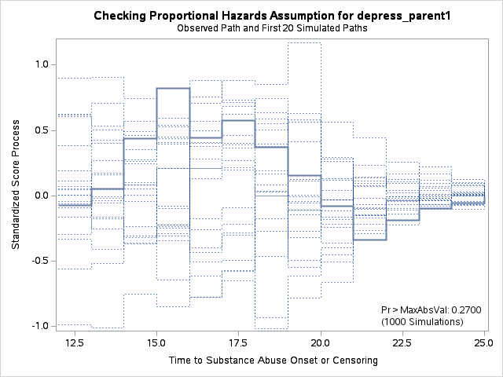

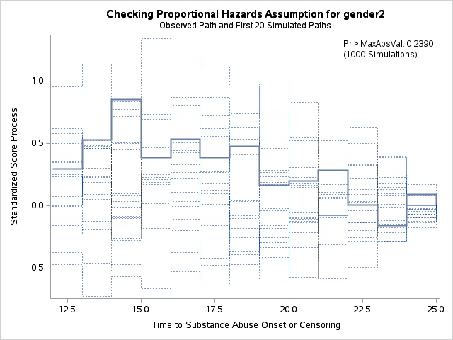

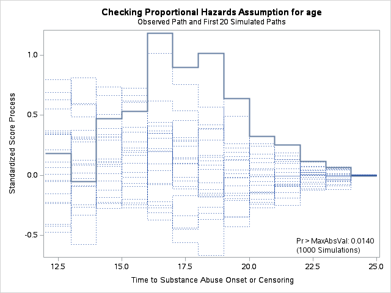

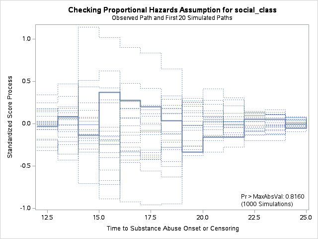

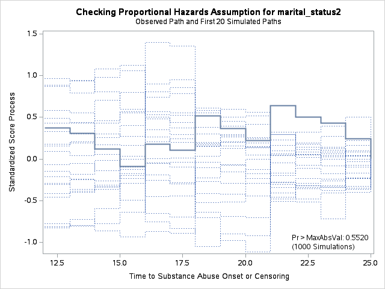

| Supremum Test for Proportionals Hazards Assumption Variable | Supremum Test for Proportionals Hazards Assumption Maximum Absolute Value | Supremum Test for Proportionals Hazards Assumption Replications | Supremum Test for Proportionals Hazards Assumption Seed | Supremum Test for Proportionals Hazards Assumption Pr > MaxAbsVal |
| --- | --- | --- | --- | --- |
| depress_parent1 | 0.8210 | 1000 | 1307583774 | 0.2700 |
| gender2 | 0.8488 | 1000 | 1307583774 | 0.2390 |
| age | 1.1851 | 1000 | 1307583774 | 0.0140 |
| social_class | 0.3715 | 1000 | 1307583774 | 0.8160 |
| marital_status2 | 0.6366 | 1000 | 1307583774 | 0.5520 |

HYPOTHESIS 2c: Cox Regression for Substance Abuse Onset

Joint effects of PRIOR DEPRESSION and PARENTAL DEPRESSION

The PHREG Procedure

| Model Information |  |  |
| --- | --- | --- |
| Data Set | WORK.SUBSTANCE_ANALYSIS |  |
| Dependent Variable | time_subst | Time to Substance Abuse Onset or Censoring |
| Censoring Variable | censor_subst | Censoring Status for Substance Abuse (1=Censored, 0=Event) |
| Censoring Value(s) | 1 |  |
| Ties Handling | BRESLOW |  |

| Number of Observations Read Number of Observations Used | 220 219 |
| --- | --- |

| Class Level Information Class | Class Level Information Value | Class Level Information Design Variables |
| --- | --- | --- |
| prior_depression | 0 | 0 |
|  | 1 | 1 |
| depress_parent | 0 | 0 |
|  | 1 | 1 |
| gender | 1 | 0 |
|  | 2 | 1 |
| marital_status | 1 | 0 |
|  | 2 | 1 |

| Summary of the Number of Event and Censored Values Total | Summary of the Number of Event and Censored Values Event | Summary of the Number of Event and Censored Values Censored | Summary of the Number of Event and Censored Values Percent Censored |
| --- | --- | --- | --- |
| 219 | 28 | 191 | 87.21 |

| Convergence Status |
| --- |
| Convergence criterion (GCONV=1E-8) satisfied. |

| Model Fit Statistics Criterion | Model Fit Statistics Without Covariates | Model Fit Statistics With Covariates |
| --- | --- | --- |
| -2 LOG L | 243.449 | 233.815 |
| AIC | 243.449 | 245.815 |
| SBC | 243.449 | 253.808 |

| Testing Global Null Hypothesis: BETA=0 Test | Testing Global Null Hypothesis: BETA=0 Chi-Square | Testing Global Null Hypothesis: BETA=0 DF | Testing Global Null Hypothesis: BETA=0 Pr > ChiSq |
| --- | --- | --- | --- |
| Likelihood Ratio | 9.6338 | 6 | 0.1409 |
| Score | 9.1500 | 6 | 0.1653 |
| Wald | 8.6812 | 6 | 0.1923 |

| Type 3 Tests Effect | Type 3 Tests DF | Type 3 Tests Wald Chi-Square | Type 3 Tests Pr > ChiSq |
| --- | --- | --- | --- |
| prior_depression | 1 | 0.2357 | 0.6273 |
| depress_parent | 1 | 4.0965 | 0.0430 |
| gender | 1 | 1.6364 | 0.2008 |
| age | 1 | 0.0774 | 0.7809 |
| social_class | 1 | 0.3522 | 0.5529 |
| marital_status | 1 | 3.1918 | 0.0740 |

| Analysis of Maximum Likelihood Estimates Parameter | Analysis of Maximum Likelihood Estimates | Analysis of Maximum Likelihood Estimates DF | Analysis of Maximum Likelihood Estimates Parameter Estimate | Analysis of Maximum Likelihood Estimates Standard Error | Analysis of Maximum Likelihood Estimates Chi-Square | Analysis of Maximum Likelihood Estimates Pr > ChiSq | Analysis of Maximum Likelihood Estimates Hazard Ratio | Analysis of Maximum Likelihood Estimates Label |
| --- | --- | --- | --- | --- | --- | --- | --- | --- |
| prior_depression | 1 | 1 | -0.19980 | 0.41156 | 0.2357 | 0.6273 | 0.819 | Prior Depression Before Substance Abuse (1=Yes, 0=No) 1 |
| depress_parent | 1 | 1 | 0.94996 | 0.46936 | 4.0965 | 0.0430 | 2.586 | Parental Depression (0=No, 1=Yes) 1 |
| gender | 2 | 1 | -0.50220 | 0.39258 | 1.6364 | 0.2008 | 0.605 | Gender (1=Male, 2=Female) 2 |
| age |  | 1 | 0.02332 | 0.08382 | 0.0774 | 0.7809 | 1.024 | Age at Interview |
| social_class |  | 1 | 0.10611 | 0.17881 | 0.3522 | 0.5529 | 1.112 | Social Class (1=Highest, 5=Lowest) |
| marital_status | 2 | 1 | -1.00641 | 0.56332 | 3.1918 | 0.0740 | 0.366 | Marital Status (1=Married, 2=Sep/Div) 2 |

HYPOTHESIS 2c: Cox Regression with PH Assumption Test

The PHREG Procedure

| Model Information |  |  |
| --- | --- | --- |
| Data Set | WORK.SUBSTANCE_ANALYSIS |  |
| Dependent Variable | time_subst | Time to Substance Abuse Onset or Censoring |
| Censoring Variable | censor_subst | Censoring Status for Substance Abuse (1=Censored, 0=Event) |
| Censoring Value(s) | 1 |  |
| Ties Handling | EFRON |  |

| Number of Observations Read Number of Observations Used | 220 219 |
| --- | --- |

| Class Level Information Class | Class Level Information Value | Class Level Information Design Variables |
| --- | --- | --- |
| prior_depression | 0 | 0 |
|  | 1 | 1 |
| depress_parent | 0 | 0 |
|  | 1 | 1 |
| gender | 1 | 0 |
|  | 2 | 1 |
| marital_status | 1 | 0 |
|  | 2 | 1 |

| Summary of the Number of Event and Censored Values Total | Summary of the Number of Event and Censored Values Event | Summary of the Number of Event and Censored Values Censored | Summary of the Number of Event and Censored Values Percent Censored |
| --- | --- | --- | --- |
| 219 | 28 | 191 | 87.21 |

| Convergence Status |
| --- |
| Convergence criterion (GCONV=1E-8) satisfied. |

| Model Fit Statistics Criterion | Model Fit Statistics Without Covariates | Model Fit Statistics With Covariates |
| --- | --- | --- |
| -2 LOG L | 243.051 | 233.295 |
| AIC | 243.051 | 245.295 |
| SBC | 243.051 | 253.288 |

| Testing Global Null Hypothesis: BETA=0 Test | Testing Global Null Hypothesis: BETA=0 Chi-Square | Testing Global Null Hypothesis: BETA=0 DF | Testing Global Null Hypothesis: BETA=0 Pr > ChiSq |
| --- | --- | --- | --- |
| Likelihood Ratio | 9.7563 | 6 | 0.1353 |
| Score | 9.2646 | 6 | 0.1592 |
| Wald | 8.7843 | 6 | 0.1861 |

| Type 3 Tests Effect | Type 3 Tests DF | Type 3 Tests Wald Chi-Square | Type 3 Tests Pr > ChiSq |
| --- | --- | --- | --- |
| prior_depression | 1 | 0.2477 | 0.6187 |
| depress_parent | 1 | 4.1367 | 0.0420 |
| gender | 1 | 1.6721 | 0.1960 |
| age | 1 | 0.0801 | 0.7771 |
| social_class | 1 | 0.3658 | 0.5453 |
| marital_status | 1 | 3.2215 | 0.0727 |

| Analysis of Maximum Likelihood Estimates Parameter | Analysis of Maximum Likelihood Estimates | Analysis of Maximum Likelihood Estimates DF | Analysis of Maximum Likelihood Estimates Parameter Estimate | Analysis of Maximum Likelihood Estimates Standard Error | Analysis of Maximum Likelihood Estimates Chi-Square | Analysis of Maximum Likelihood Estimates Pr > ChiSq | Analysis of Maximum Likelihood Estimates Hazard Ratio | Analysis of Maximum Likelihood Estimates Label |
| --- | --- | --- | --- | --- | --- | --- | --- | --- |
| prior_depression | 1 | 1 | -0.20481 | 0.41149 | 0.2477 | 0.6187 | 0.815 | Prior Depression Before Substance Abuse (1=Yes, 0=No) 1 |
| depress_parent | 1 | 1 | 0.95500 | 0.46955 | 4.1367 | 0.0420 | 2.599 | Parental Depression (0=No, 1=Yes) 1 |
| gender | 2 | 1 | -0.50743 | 0.39242 | 1.6721 | 0.1960 | 0.602 | Gender (1=Male, 2=Female) 2 |
| age |  | 1 | 0.02369 | 0.08370 | 0.0801 | 0.7771 | 1.024 | Age at Interview |
| social_class |  | 1 | 0.10824 | 0.17896 | 0.3658 | 0.5453 | 1.114 | Social Class (1=Highest, 5=Lowest) |
| marital_status | 2 | 1 | -1.01112 | 0.56334 | 3.2215 | 0.0727 | 0.364 | Marital Status (1=Married, 2=Sep/Div) 2 |

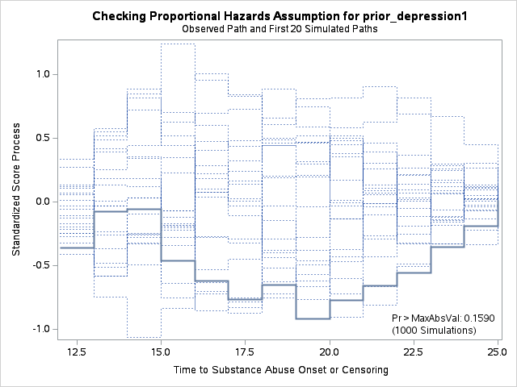

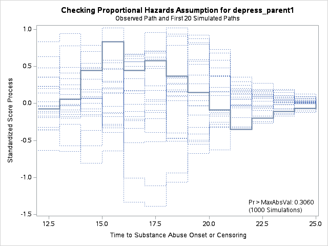

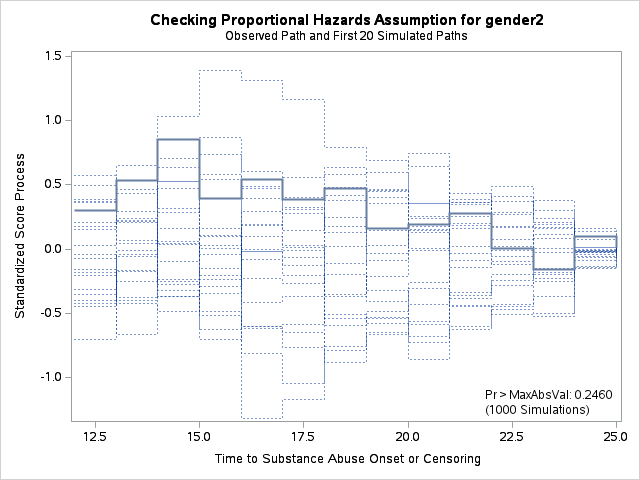

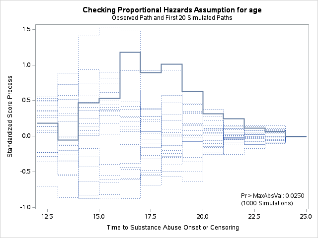

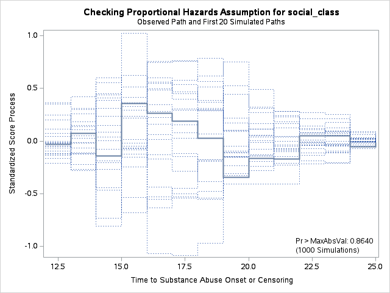

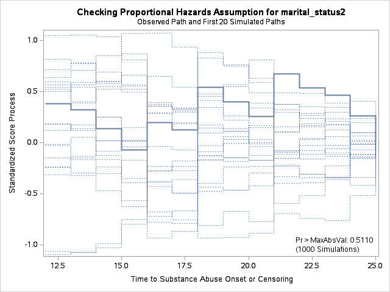

| Supremum Test for Proportionals Hazards Assumption Variable | Supremum Test for Proportionals Hazards Assumption Maximum Absolute Value | Supremum Test for Proportionals Hazards Assumption Replications | Supremum Test for Proportionals Hazards Assumption Seed | Supremum Test for Proportionals Hazards Assumption Pr > MaxAbsVal |
| --- | --- | --- | --- | --- |
| prior_depression1 | 0.9196 | 1000 | 1187171292 | 0.1590 |
| depress_parent1 | 0.8316 | 1000 | 1187171292 | 0.3060 |
| gender2 | 0.8560 | 1000 | 1187171292 | 0.2460 |
| age | 1.1813 | 1000 | 1187171292 | 0.0250 |
| social_class | 0.3582 | 1000 | 1187171292 | 0.8640 |
| marital_status2 | 0.6729 | 1000 | 1187171292 | 0.5110 |